# Logistic regression and prediction

Gerko Vink

The aim of this document is to highlight some workflows for generating confidence intervals and prediction intervals for individual values. I outline parametric and bootstrap approaches and demonstrate that these approaches are equivalent; at least for a sufficient number of bootstraps.

# Load required packages

```r
library(tidyverse)
library(magrittr)
```

```r
library(purrr)
library(ggplot2)
library(GGally)
library(ciTools)
library(caret)
library(marginaleffects)
library(insight)
library(ISLR)
set.seed(123)
```

# Draw 100 bootstrapped sets

```r
Default %<>%
  mutate(row = 1:nrow(Default))
boot <- replicate(n = 100,
                  expr = Default[sample(nrow(Default),
                                        replace = TRUE), ],
                  simplify = FALSE)
```

The `simplify = FALSE` statement is to keep the list structure in the object `boot`. I can then, later on, use this list structure to run my functional programming over.

# Fit logistic model on true data set

This is the baseline model on the observed (not bootstrapped) data

```r
fit <- Default %$%
  glm(default  ~ balance + income + student, family = binomial(link = "logit"))
```

## Coefficients

Model `fit` has the following coefficients:

```r
fit %>% coef()
```

```
##   (Intercept)       balance        income    studentYes
## -1.086905e+01  5.736505e-03  3.033450e-06 -6.467758e-01
```

## Parameter CI’s

Model `fit` has the following corresponding coefficients confidence intervals (95%):

```r
fit %>% confint
```

```
##                     2.5 %        97.5 %
## (Intercept) -1.185902e+01 -9.928174e+00
## balance      5.294898e-03  6.204587e-03
## income      -1.304712e-05  1.912447e-05
## studentYes  -1.109018e+00 -1.822147e-01
```

## Standard errors

The coefficient standard errors are:

```r
fit %>% summary %>% .$coefficients
```

```
##                  Estimate   Std. Error    z value      Pr(>|z|)
## (Intercept) -1.086905e+01 4.922555e-01 -22.080088 4.911280e-108
## balance      5.736505e-03 2.318945e-04  24.737563 4.219578e-135
## income       3.033450e-06 8.202615e-06   0.369815  7.115203e-01
## studentYes  -6.467758e-01 2.362525e-01  -2.737646  6.188063e-03
```

# Fit logistic models on all bootstrap sets

Now we repeat the model fit on all bootstrapped sets. I use `purrr::map()` to fit the same generalized linear model on each listed dimension in `boot`, where every listed dimension contains a single bootstrapped sample from `Default`.

```r
bootfit <- boot %>%
  map(~.x %$%
        glm(default  ~ balance + income + student,
            family = binomial(link = "logit")))
```

## Bootstrapped Coefficients

The average bootstrapped coefficient are:

```r
bootcoef <- bootfit %>%
  map(~.x %>% coef()) %>%
  do.call("rbind", .) %>%
  as_tibble()

bootcoef %>% colMeans()
```

```
##   (Intercept)       balance        income    studentYes
## -1.088869e+01  5.743384e-03  3.243917e-06 -6.457210e-01
```

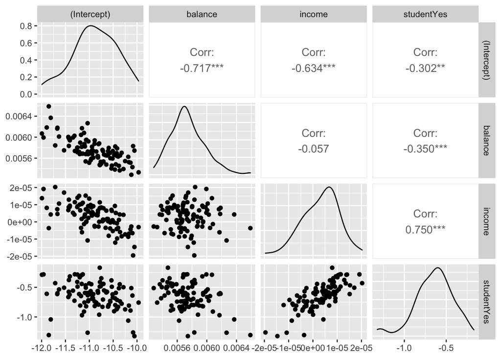

```r
ggpairs(bootcoef)
```

## Bootstrapped CI’s

The average bootstrapped percentile-based confidence intervals are:

```r
bootcoef %>%
  sapply(., function(x) quantile(x, c(.025, .975))) %>% t()
```

```
##                      2.5%         97.5%
## (Intercept) -1.187249e+01 -1.008893e+01
## balance      5.374165e-03  6.227218e-03
## income      -1.147601e-05  1.620489e-05
## studentYes  -1.263833e+00 -2.814348e-01
```

## Bootstrapped SE’s

The correponding bootstrapped standard errors across the bootstrapped parameters are :

```r
bootcoef %>%
  sapply(., sd)
```

```
##  (Intercept)      balance       income   studentYes
## 4.650381e-01 2.333902e-04 7.445117e-06 2.270330e-01
```

# Comparisons

I now compare the original parametrically obtained estimates to the estimates obtained via the bootstrap.

## Coefficients

```r
data.frame(original = fit$coefficients,
           bootstrap = bootcoef %>% colMeans())
```

```
##                  original     bootstrap
## (Intercept) -1.086905e+01 -1.088869e+01
## balance      5.736505e-03  5.743384e-03
## income       3.033450e-06  3.243917e-06
## studentYes  -6.467758e-01 -6.457210e-01
```

## Confidence intervals

```r
list(original = fit %>% confint(),
     bootstrap = bootcoef %>%
       sapply(., function(x) quantile(x, c(.025, .975))) %>% t())
```

```
## $original
##                     2.5 %        97.5 %
## (Intercept) -1.185902e+01 -9.928174e+00
## balance      5.294898e-03  6.204587e-03
## income      -1.304712e-05  1.912447e-05
## studentYes  -1.109018e+00 -1.822147e-01
##
## $bootstrap
##                      2.5%         97.5%
## (Intercept) -1.187249e+01 -1.008893e+01
## balance      5.374165e-03  6.227218e-03
## income      -1.147601e-05  1.620489e-05
## studentYes  -1.263833e+00 -2.814348e-01
```

## Standard Errors

```r
data.frame(original = fit %>% summary %>% .$coefficients %>% .[, 2],
           bootstrap = bootcoef %>%
  sapply(., sd))
```

```
##                 original    bootstrap
## (Intercept) 4.922555e-01 4.650381e-01
## balance     2.318945e-04 2.333902e-04
## income      8.202615e-06 7.445117e-06
## studentYes  2.362525e-01 2.270330e-01
```

We can see that the bootstrap is a valid approximation to the parameters and statistics obtained on the original data set.

# Individual intervals

Now let’s calculate individual intervals via the bootstrap

## Bootstrap individual interval

The following codeblock calculates for every case in the `Default` data the predicted value, the standard error of the predicted value and the corresponding row number. I combine these into a `tibble` with 3 columns: one for the rows, one for the predictions and one for the corresponding standard error.

```r
# create matrix with size bootstrap \times cases
pred.matrix <- bootfit %>%
  map(~.x %>% predict()) %>%
  do.call("rbind", .)

se.matrix <- bootfit %>%
  map(~.x %>% predict(se = TRUE) %>% .$se.fit) %>%
  do.call("rbind", .)

rows.matrix <- boot %>%
  map(~.x %>% .$row)  %>%
  do.call("rbind", .)

# row predictions
pred.data <- data.frame(rows = c(rows.matrix),
                        pred = c(pred.matrix),
                        se = c(se.matrix)) %>%
  as_tibble()
```

```r
# calculate centroids and quantiles
pred <- pred.data %>% group_by(rows) %>%
  summarize(est = mean(pred),
            se.fit = mean(se),
            lwr = est - 1.96 * se.fit, #parametric SE
            upr = est + 1.96 * se.fit, #parametric SE
            lwr.q = quantile(pred, .025),
            upr.q = quantile(pred, .975))

# convert to prob
pred %<>% mutate(prob = plogis(est),
                 plwr = plogis(lwr),
                 pupr = plogis(upr),
                 plwr.q = plogis(lwr.q),
                 pupr.q = plogis(upr.q))

# head of predictions calculated
pred
```

```
## # A tibble: 10,000 × 12
##     rows    est se.fit    lwr    upr  lwr.q  upr.q      prob      plwr      pupr
##    <int>  <dbl>  <dbl>  <dbl>  <dbl>  <dbl>  <dbl>     <dbl>     <dbl>     <dbl>
##  1     1  -6.53  0.210  -6.94  -6.12  -6.96  -6.17 0.00145   0.000963  0.00219
##  2     2  -6.81  0.243  -7.29  -6.33  -7.35  -6.35 0.00110   0.000685  0.00178
##  3     3  -4.64  0.157  -4.94  -4.33  -5.02  -4.42 0.00960   0.00708   0.0130
##  4     4  -7.72  0.254  -8.21  -7.22  -8.20  -7.36 0.000445  0.000271  0.000731
##  5     5  -6.27  0.198  -6.66  -5.88  -6.64  -5.94 0.00189   0.00128   0.00278
##  6     6  -6.27  0.235  -6.73  -5.80  -6.75  -5.83 0.00190   0.00120   0.00300
##  7     7  -6.04  0.224  -6.48  -5.60  -6.48  -5.77 0.00237   0.00153   0.00368
##  8     8  -6.82  0.240  -7.29  -6.35  -7.26  -6.45 0.00109   0.000684  0.00175
##  9     9  -4.10  0.126  -4.35  -3.86  -4.29  -3.89 0.0162    0.0127    0.0207
## 10    10 -10.8   0.378 -11.5  -10.0  -11.5  -10.2  0.0000213 0.0000102 0.0000448
## # … with 9,990 more rows, and 2 more variables: plwr.q <dbl>, pupr.q <dbl>
```

## Compare predictions

If we compare the predicted values obtained on the original data to the predicted values obtained via the bootstrap in a Q-Q plot, we find that their distribution is very close. Increasing the number of bootstraps will bring them closer.

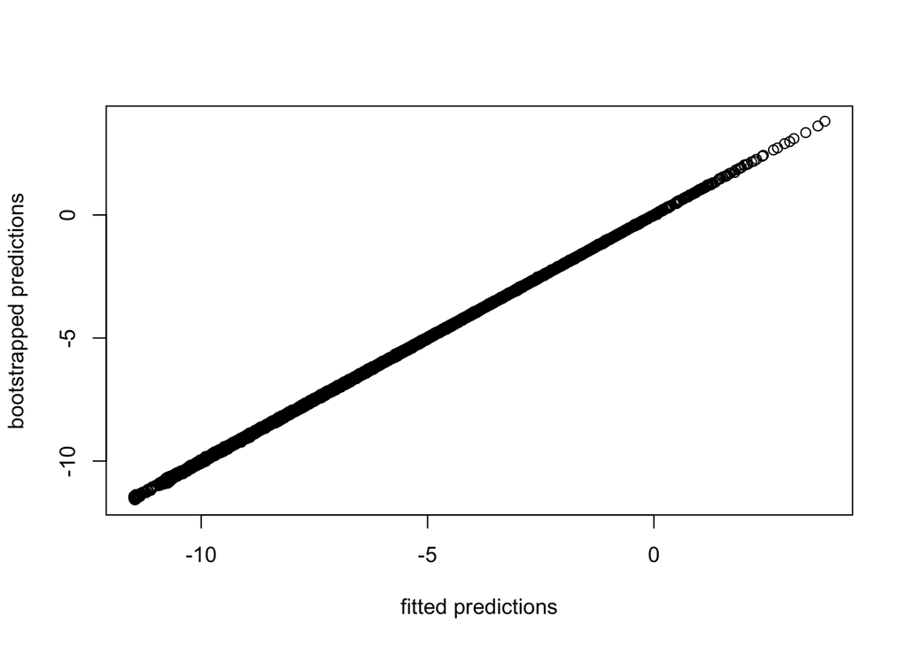

```r
plot(x = fit %>% predict,
     y = pred$est,
     xlab = "fitted predictions",
     ylab = "bootstrapped predictions")
```

## Compare se’s

The same holds for the estimated standard errors.

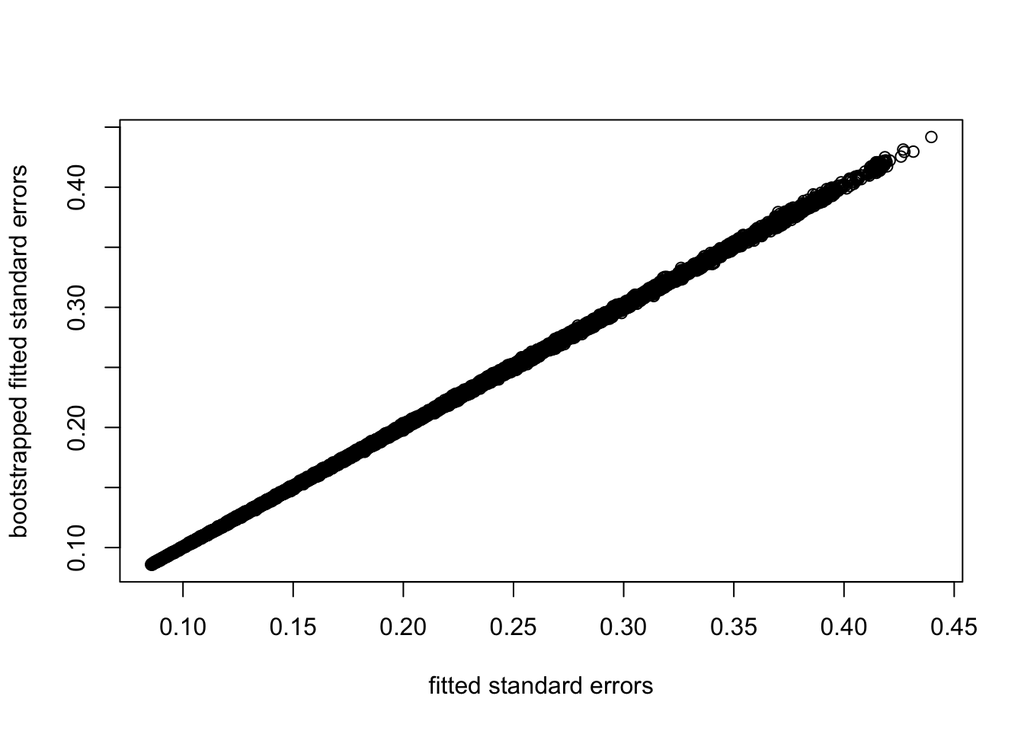

```r
y_se <- fit %>%
  predict(se = TRUE) %>%
  as.data.frame()
plot(x = y_se$se.fit,
     y = pred$se.fit,
     xlab = "fitted standard errors",
     ylab = "bootstrapped fitted standard errors")
```

## Individual interval true model

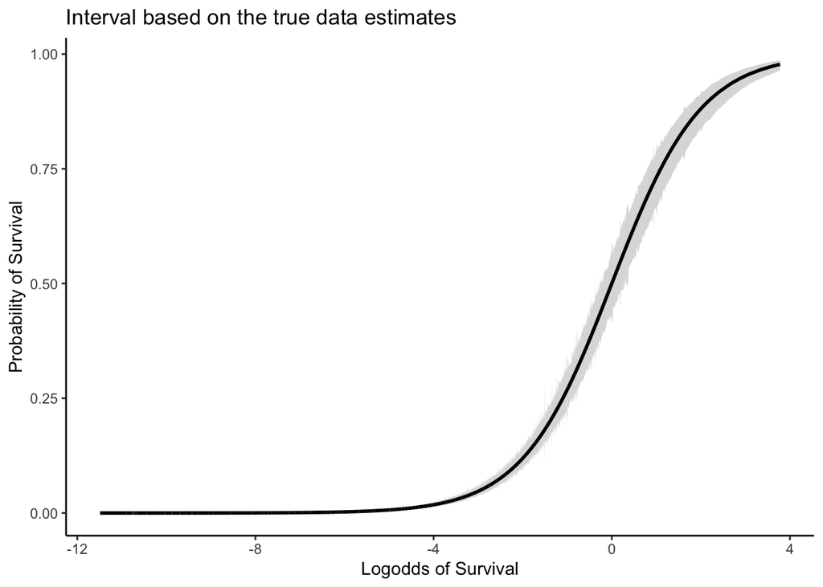

```r
fit %>%
  predict(se = TRUE) %>%
  as.data.frame() %>%
  mutate(prob = plogis(fit),
         lwr = plogis(fit - 1.96 * se.fit),
         upr = plogis(fit + 1.96 * se.fit)) %>%
  ggplot(aes(x = fit, y = prob)) +
  geom_ribbon(aes(ymin = lwr, ymax = upr), alpha = .2) +
  geom_line(lwd = 1) + ylab("Probability of Survival") + xlab("Logodds of Survival") + ggtitle("Interval based on the true data estimates") + theme_classic()
```

## Individual interval bootstrapped se

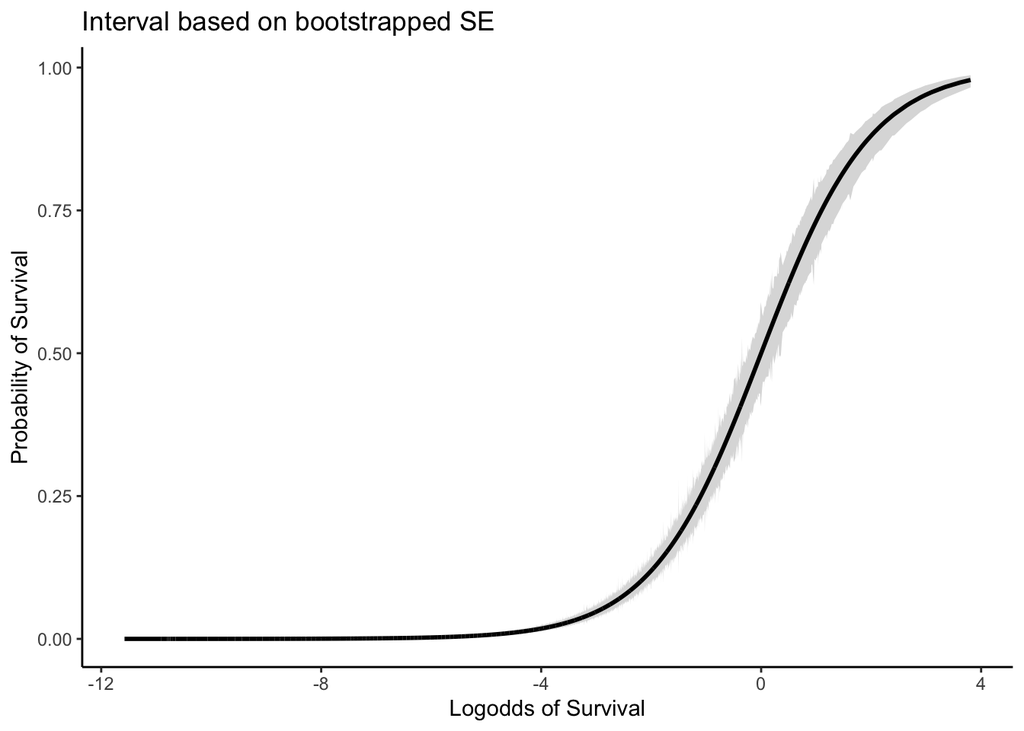

```r
pred %>%
  ggplot(aes(x = est, y = prob)) +
  geom_ribbon(aes(ymin = plwr, ymax = pupr), alpha = .2) +
  geom_line(lwd = 1) + ylab("Probability of Survival") + xlab("Logodds of Survival") + ggtitle("Interval based on bootstrapped SE") + theme_classic()
```

## Individual interval bootstrapped quantile

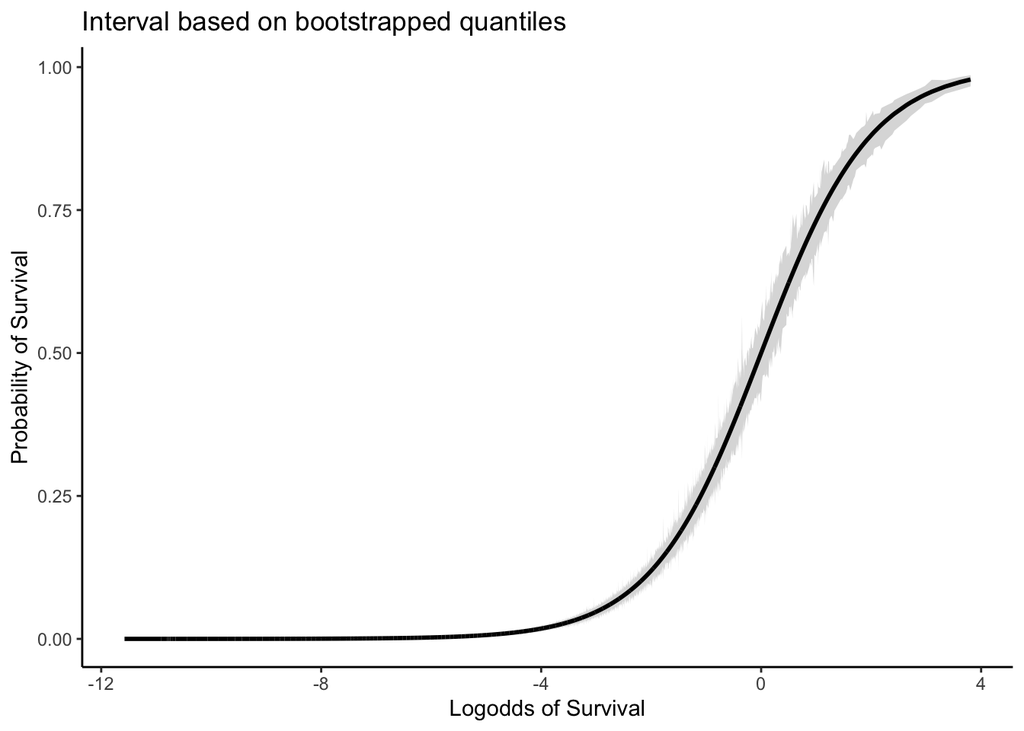

```r
pred %>%
  ggplot(aes(x = est, y = prob)) +
  geom_ribbon(aes(ymin = plwr.q, ymax = pupr.q), alpha = .2) +
  geom_line(lwd = 1) + ylab("Probability of Survival") + xlab("Logodds of Survival") + ggtitle("Interval based on bootstrapped quantiles") + theme_classic()
```

# Confusion Matrices

## Original data predictions (reference = truth)

```r
yhat <- fit %>%
  predict(type = "response")

yhat <- ifelse(yhat > .5, "Yes", "No") %>%  # easy threshold for brevity
  as.factor()

confusionMatrix(yhat, Default$default)
```

```
## Confusion Matrix and Statistics
##
##           Reference
## Prediction   No  Yes
##        No  9627  228
##        Yes   40  105
##
##                Accuracy : 0.9732
##                  95% CI : (0.9698, 0.9763)
##     No Information Rate : 0.9667
##     P-Value [Acc > NIR] : 0.0001044
##
##                   Kappa : 0.4278
##
##  Mcnemar's Test P-Value : < 2.2e-16
##
##             Sensitivity : 0.9959
##             Specificity : 0.3153
##          Pos Pred Value : 0.9769
##          Neg Pred Value : 0.7241
##              Prevalence : 0.9667
##          Detection Rate : 0.9627
##    Detection Prevalence : 0.9855
##       Balanced Accuracy : 0.6556
##
##        'Positive' Class : No
##
```

## Bootstrapped predictions (reference = truth)

```r
predicted <- ifelse(pred$prob > .5, "Yes", "No") %>%
  as.factor()

confusionMatrix(predicted, Default$default)
```

```
## Confusion Matrix and Statistics
##
##           Reference
## Prediction   No  Yes
##        No  9628  228
##        Yes   39  105
##
##                Accuracy : 0.9733
##                  95% CI : (0.9699, 0.9764)
##     No Information Rate : 0.9667
##     P-Value [Acc > NIR] : 8.229e-05
##
##                   Kappa : 0.4288
##
##  Mcnemar's Test P-Value : < 2.2e-16
##
##             Sensitivity : 0.9960
##             Specificity : 0.3153
##          Pos Pred Value : 0.9769
##          Neg Pred Value : 0.7292
##              Prevalence : 0.9667
##          Detection Rate : 0.9628
##    Detection Prevalence : 0.9856
##       Balanced Accuracy : 0.6556
##
##        'Positive' Class : No
##
```

## Bootstrapped vs original data predictions (reference = bootstrap)

```r
confusionMatrix(yhat, predicted) # bootstrap is reference
```

```
## Confusion Matrix and Statistics
##
##           Reference
## Prediction   No  Yes
##        No  9855    0
##        Yes    1  144
##
##                Accuracy : 0.9999
##                  95% CI : (0.9994, 1)
##     No Information Rate : 0.9856
##     P-Value [Acc > NIR] : <2e-16
##
##                   Kappa : 0.9965
##
##  Mcnemar's Test P-Value : 1
##
##             Sensitivity : 0.9999
##             Specificity : 1.0000
##          Pos Pred Value : 1.0000
##          Neg Pred Value : 0.9931
##              Prevalence : 0.9856
##          Detection Rate : 0.9855
##    Detection Prevalence : 0.9855
##       Balanced Accuracy : 0.9999
##
##        'Positive' Class : No
##
```

# Checks

## Check the individual`se.fit`

Let’s identify if we can replicate the `se.fit` calculation. First, lets manually calculate the `se.fit` that is produced by `predict()`.

```r
# For the whole data
pred <- predict(fit, se = TRUE)
X <- model.matrix(fit) # Design matrix
sefun <- function(x) sqrt(t(x) %*% vcov(fit) %*% x)
SE.manual <- apply(X, 1, sefun)
all.equal(pred$se.fit,SE.manual) # SAME
```

```
## [1] TRUE
```

That works.

Some additional checks across packages.

```r
predict(fit, se.fit = TRUE) %>%
  as.data.frame() %>%
  mutate(prob = plogis(fit),
         lwr = plogis(fit - qt(.975, Inf) * se.fit),
         upr = plogis(fit + qt(.975, Inf) * se.fit)) %>% head()
```

```
##         fit    se.fit residual.scale         prob          lwr          upr
## 1 -6.549544 0.2113733              1 0.0014287239 0.0009445775 0.0021604847
## 2 -6.791338 0.2421776              1 0.0011222039 0.0006984157 0.0018026764
## 3 -4.614261 0.1553261              1 0.0098122716 0.0072556382 0.0132577426
## 4 -7.724689 0.2537409              1 0.0004415893 0.0002686019 0.0007259049
## 5 -6.245449 0.1969054              1 0.0019355062 0.0013166114 0.0028444940
## 6 -6.217871 0.2326672              1 0.0019895182 0.0012618792 0.0031354192
```

```r
# from package insight
get_predicted_ci(fit,
                 predictions = get_predicted(fit),
                 ci_type = "prediction") %>%
  head()
```

```
##   CI_low.Predicted    CI_low.SE CI_low.CI_low CI_low.CI_high CI_high.Predicted
## 1             -Inf 0.0031842396  1.801975e-05    0.102012228               Inf
## 2             -Inf 0.0007350733  3.106265e-04    0.004045618               Inf
## 3             -Inf 0.0155567954  4.294978e-04    0.186023720               Inf
## 4             -Inf 0.0007972156  1.281811e-05    0.014997824               Inf
## 5             -Inf 0.0037426064  4.350036e-05    0.079570276               Inf
## 6             -Inf 0.0008803620  8.352996e-04    0.004731086               Inf
##     CI_high.SE CI_high.CI_low CI_high.CI_high
## 1 0.0031842396   1.801975e-05     0.102012228
## 2 0.0007350733   3.106265e-04     0.004045618
## 3 0.0155567954   4.294978e-04     0.186023720
## 4 0.0007972156   1.281811e-05     0.014997824
## 5 0.0037426064   4.350036e-05     0.079570276
## 6 0.0008803620   8.352996e-04     0.004731086
```

## Are prediction intervals wider than confidence intervals

Of course they are. Some proof for a linear model:

```r
fit0 <- lm(hgt ~ age, data = mice::boys)

# confidence interval
predict(fit0, interval = "confidence") %>% head()
```

```
##         fit      lwr      upr
## 3  70.93310 69.67496 72.19124
## 4  70.95288 69.69500 72.21076
## 18 71.07815 69.82194 72.33437
## 23 71.09793 69.84198 72.35389
## 28 71.11112 69.85534 72.36690
## 36 71.15068 69.89543 72.40593
```

```r
# prediction interval
predict(fit0, interval = "prediction") %>% head()
```

```
## Warning in predict.lm(fit0, interval = "prediction"): predictions on current data refer to _future_ responses
```

```
##         fit      lwr      upr
## 3  70.93310 50.69346 91.17274
## 4  70.95288 50.71326 91.19250
## 18 71.07815 50.83863 91.31767
## 23 71.09793 50.85843 91.33744
## 28 71.11112 50.87163 91.35061
## 36 71.15068 50.91122 91.39014
```

Note that the warning states that the predictions refer to future responses. Hence, the larger variance and wider intervals.